# IODS course project

## Standardization

Thus, let’s stardardize them. Standardization should work the following way:

“In the scaling we subtract the column means from the corresponding columns and divide the difference with standard deviation.” (straight from the exercise set, wanted just include it here)

$$scaled(x) = \frac{x - mean(x)}{
sd(x)}$$
We can scale the variables by using scale() function.

```r
# center and standardize variables
boston_scaled <- scale(Boston)

# summaries of the scaled variables
summary(boston_scaled)
```

```
##       crim                 zn               indus              chas
##  Min.   :-0.419367   Min.   :-0.48724   Min.   :-1.5563   Min.   :-0.2723
##  1st Qu.:-0.410563   1st Qu.:-0.48724   1st Qu.:-0.8668   1st Qu.:-0.2723
##  Median :-0.390280   Median :-0.48724   Median :-0.2109   Median :-0.2723
##  Mean   : 0.000000   Mean   : 0.00000   Mean   : 0.0000   Mean   : 0.0000
##  3rd Qu.: 0.007389   3rd Qu.: 0.04872   3rd Qu.: 1.0150   3rd Qu.:-0.2723
##  Max.   : 9.924110   Max.   : 3.80047   Max.   : 2.4202   Max.   : 3.6648
##       nox                rm               age               dis
##  Min.   :-1.4644   Min.   :-3.8764   Min.   :-2.3331   Min.   :-1.2658
##  1st Qu.:-0.9121   1st Qu.:-0.5681   1st Qu.:-0.8366   1st Qu.:-0.8049
##  Median :-0.1441   Median :-0.1084   Median : 0.3171   Median :-0.2790
##  Mean   : 0.0000   Mean   : 0.0000   Mean   : 0.0000   Mean   : 0.0000
##  3rd Qu.: 0.5981   3rd Qu.: 0.4823   3rd Qu.: 0.9059   3rd Qu.: 0.6617
##  Max.   : 2.7296   Max.   : 3.5515   Max.   : 1.1164   Max.   : 3.9566
##       rad               tax             ptratio            black
##  Min.   :-0.9819   Min.   :-1.3127   Min.   :-2.7047   Min.   :-3.9033
##  1st Qu.:-0.6373   1st Qu.:-0.7668   1st Qu.:-0.4876   1st Qu.: 0.2049
##  Median :-0.5225   Median :-0.4642   Median : 0.2746   Median : 0.3808
##  Mean   : 0.0000   Mean   : 0.0000   Mean   : 0.0000   Mean   : 0.0000
##  3rd Qu.: 1.6596   3rd Qu.: 1.5294   3rd Qu.: 0.8058   3rd Qu.: 0.4332
##  Max.   : 1.6596   Max.   : 1.7964   Max.   : 1.6372   Max.   : 0.4406
##      lstat              medv
##  Min.   :-1.5296   Min.   :-1.9063
##  1st Qu.:-0.7986   1st Qu.:-0.5989
##  Median :-0.1811   Median :-0.1449
##  Mean   : 0.0000   Mean   : 0.0000
##  3rd Qu.: 0.6024   3rd Qu.: 0.2683
##  Max.   : 3.5453   Max.   : 2.9865
```

The variables are all new centered around 0. The highest max-value is in “crim”-variable with max of 9.9.

To use this scaled version later, let’s create this as a dataframe.

```r
boston_scaled <- as.data.frame(boston_scaled)
```

## Factor

Then let’s turn “crim” variable to factor.

First, let’s create quantile vector of crime.

```r
# summary of the scaled crime rate
summary(boston_scaled$crim)
```

```
##      Min.   1st Qu.    Median      Mean   3rd Qu.      Max.
## -0.419367 -0.410563 -0.390280  0.000000  0.007389  9.924110
```

```r
# create a quantile vector of crim and print it
bins <- quantile(boston_scaled$crim)
bins
```

```
##           0%          25%          50%          75%         100%
## -0.419366929 -0.410563278 -0.390280295  0.007389247  9.924109610
```

Let’s then create crime vector based on bins created in previous chunk:

```r
crime <- cut(boston_scaled$crim, breaks = bins, include.lowest = TRUE, labels = c("low", "med_low", "med_high", "high"))
table(crime)
```

```
## crime
##      low  med_low med_high     high
##      127      126      126      127
```

Now, let’s add the new variable to the old data set.

```r
# remove original crim from the dataset
boston_scaled <- dplyr::select(boston_scaled, -crim)

# add the new categorical value to scaled data
boston_scaled <- data.frame(boston_scaled, crime)
```

Then, for clustering purposes, let’s create train and test data sets. Let’s take a random sample of rows in boston_scaled. Let’s choose 80% of the rows to be used in training set. The rest will be used in the test set.

```r
# number of rows in the Boston dataset
n <- nrow(boston_scaled)

# choose randomly 80% of the rows
ind <- sample(n,  size = n * 0.8)

# create train set
train <- boston_scaled[ind,]

# create test set
test <- boston_scaled[-ind,]

# save the correct classes from test data
correct_classes <- test$crime

# remove the crime variable from test data
test <- dplyr::select(test, -crime)
```

## Lda

Then, let’s use lda. We use the categorical crime rate as the target variable (lda takes as its first argument a formula with target variable and predictor variables) and all the other variables in the dataset as predictor variables.

I write some theory of LDA, mostly just for myself. The theory is from StatQuest video (https://www.youtube.com/watch?v=azXCzI57Yfc):

Lda creates a new axis tha maximizes the separtation of the categories. It maximizes the distance between the means of the categorie while minimizing the variation within each category. With multiple categories we first find a point central to all data and then measure distance between central point of each categories and central point of all data. Then we maximize the the distance between each category and the central point while minimizing the scatter for each category.

```r
# linear discriminant analysis
lda.fit <- lda(crime ~ ., data = train)

# print the lda.fit object
lda.fit
```

```
## Call:
## lda(crime ~ ., data = train)
##
## Prior probabilities of groups:
##       low   med_low  med_high      high
## 0.2425743 0.2475248 0.2574257 0.2524752
##
## Group means:
##                  zn      indus         chas        nox          rm        age
## low       0.9318618 -0.8956288 -0.111631099 -0.8520611  0.44108891 -0.8855762
## med_low  -0.1071344 -0.2726359  0.042638951 -0.5806646 -0.14571860 -0.3223896
## med_high -0.3701526  0.1492341  0.106238263  0.4214253 -0.01243943  0.4405187
## high     -0.4872402  1.0171096 -0.002135914  1.1040297 -0.39440367  0.8498098
##                 dis        rad        tax    ptratio       black       lstat
## low       0.8277600 -0.6970982 -0.7228615 -0.3452144  0.37608514 -0.76027712
## med_low   0.3247614 -0.5649777 -0.4888369 -0.0626037  0.31489469 -0.11874470
## med_high -0.3575650 -0.4606439 -0.3515925 -0.2885820  0.07930671  0.06334092
## high     -0.8585379  1.6382099  1.5141140  0.7808718 -0.68211869  0.87113916
##                  medv
## low       0.488491142
## med_low   0.008610719
## med_high  0.063866406
## high     -0.639317017
##
## Coefficients of linear discriminants:
##                 LD1          LD2         LD3
## zn       0.09548060  0.675375889 -0.94137076
## indus    0.05175464 -0.203738794  0.40970200
## chas    -0.02714309 -0.001767595  0.18297930
## nox      0.40116363 -0.740922231 -1.49176046
## rm       0.04043109  0.001202993 -0.17717002
## age      0.20295907 -0.445664490 -0.11735713
## dis     -0.01481562 -0.319668424  0.13031815
## rad      3.60111488  0.876168087  0.01937967
## tax      0.03965746  0.069983179  0.52492235
## ptratio  0.14638405  0.040864019 -0.35105532
## black   -0.07932654  0.051219652  0.11749532
## lstat    0.19421675 -0.229959558  0.41911516
## medv     0.09091222 -0.402728420 -0.07614688
##
## Proportion of trace:
##    LD1    LD2    LD3
## 0.9566 0.0314 0.0119
```

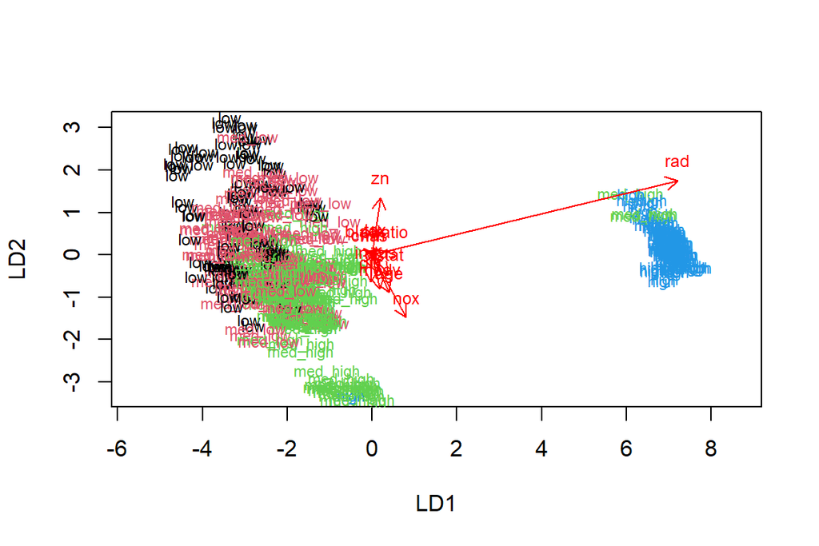

```r
# the function for lda biplot arrows
lda.arrows <- function(x, myscale = 1, arrow_heads = 0.1, color = "red", tex = 0.75, choices = c(1,2)){
  heads <- coef(x)
  arrows(x0 = 0, y0 = 0,
         x1 = myscale * heads[,choices[1]],
         y1 = myscale * heads[,choices[2]], col=color, length = arrow_heads)
  text(myscale * heads[,choices], labels = row.names(heads),
       cex = tex, col=color, pos=3)
}

# target classes as numeric
classes <- as.numeric(train$crime)

# plot the lda results
plot(lda.fit, dimen = 2, col = classes, pch = classes)
lda.arrows(lda.fit, myscale = 2)
```

The plot shows some separation between the categories in the data based on crime variable. If I interpret this correctly, on first axis/component/LD1, the data can be separated to one certain cluster on the right which has big connection with “rad” variable and a rest of the cluster on the left. The data is then also separable futher on second axis, y-axis/LD2-axis which separates especially the cluster on the left to cluster with a lot of low-crime values and cluster of med_high crime values.

Let’s then predict crime classes with LDA model. We can then compare the predictions to corrected results using correct_classes variable created earlier.

```r
# predict classes with test data
lda.pred <- predict(lda.fit, newdata = test)

# cross tabulate the results
table(correct = correct_classes, predicted = lda.pred$class)
```

```
##           predicted
## correct    low med_low med_high high
##   low       17      12        0    0
##   med_low    3      19        4    0
##   med_high   0       5       14    3
##   high       0       0        0   25
```

## Distances

Then, let’s calculate the distances between the observations. First, let’s reload the data set.

```r
library(MASS)
data("Boston")
```

Let’s scale the data set to get combarable distances.

```r
boston_scaled2 <- scale(Boston)

# summaries of the scaled variables
summary(boston_scaled2)
```

```
##       crim                 zn               indus              chas
##  Min.   :-0.419367   Min.   :-0.48724   Min.   :-1.5563   Min.   :-0.2723
##  1st Qu.:-0.410563   1st Qu.:-0.48724   1st Qu.:-0.8668   1st Qu.:-0.2723
##  Median :-0.390280   Median :-0.48724   Median :-0.2109   Median :-0.2723
##  Mean   : 0.000000   Mean   : 0.00000   Mean   : 0.0000   Mean   : 0.0000
##  3rd Qu.: 0.007389   3rd Qu.: 0.04872   3rd Qu.: 1.0150   3rd Qu.:-0.2723
##  Max.   : 9.924110   Max.   : 3.80047   Max.   : 2.4202   Max.   : 3.6648
##       nox                rm               age               dis
##  Min.   :-1.4644   Min.   :-3.8764   Min.   :-2.3331   Min.   :-1.2658
##  1st Qu.:-0.9121   1st Qu.:-0.5681   1st Qu.:-0.8366   1st Qu.:-0.8049
##  Median :-0.1441   Median :-0.1084   Median : 0.3171   Median :-0.2790
##  Mean   : 0.0000   Mean   : 0.0000   Mean   : 0.0000   Mean   : 0.0000
##  3rd Qu.: 0.5981   3rd Qu.: 0.4823   3rd Qu.: 0.9059   3rd Qu.: 0.6617
##  Max.   : 2.7296   Max.   : 3.5515   Max.   : 1.1164   Max.   : 3.9566
##       rad               tax             ptratio            black
##  Min.   :-0.9819   Min.   :-1.3127   Min.   :-2.7047   Min.   :-3.9033
##  1st Qu.:-0.6373   1st Qu.:-0.7668   1st Qu.:-0.4876   1st Qu.: 0.2049
##  Median :-0.5225   Median :-0.4642   Median : 0.2746   Median : 0.3808
##  Mean   : 0.0000   Mean   : 0.0000   Mean   : 0.0000   Mean   : 0.0000
##  3rd Qu.: 1.6596   3rd Qu.: 1.5294   3rd Qu.: 0.8058   3rd Qu.: 0.4332
##  Max.   : 1.6596   Max.   : 1.7964   Max.   : 1.6372   Max.   : 0.4406
##      lstat              medv
##  Min.   :-1.5296   Min.   :-1.9063
##  1st Qu.:-0.7986   1st Qu.:-0.5989
##  Median :-0.1811   Median :-0.1449
##  Mean   : 0.0000   Mean   : 0.0000
##  3rd Qu.: 0.6024   3rd Qu.: 0.2683
##  Max.   : 3.5453   Max.   : 2.9865
```

Let’s then calculate distances. Let’s use euclidean and manhattan distance measures and print summary of both of them for comparison.

```r
# euclidean distance matrix
dist_eu <- dist(boston_scaled2)

# look at the summary of the distances
summary(dist_eu)
```

```
##    Min. 1st Qu.  Median    Mean 3rd Qu.    Max.
##  0.1343  3.4625  4.8241  4.9111  6.1863 14.3970
```

```r
# manhattan distance matrix
dist_man <- dist(boston_scaled2, method = "manhattan")

# look at the summary of the distances
summary(dist_man)
```

```
##    Min. 1st Qu.  Median    Mean 3rd Qu.    Max.
##  0.2662  8.4832 12.6090 13.5488 17.7568 48.8618
```

Distances might not tell much here. But counting distances is at the bottom of clustering, for example K-means clustering. Counting distances is part of analyzing the similarity of the data and different observations.